# DATASCI 101: Introduction to AI Applications

Lecture 11: RAG, Semantic Search, and Grounding AI

Danilo Freire

danilo.freire@emory.edu

Department of Data and Decision Sciences  
Emory University

# Welcome back! 📚

## Recap of last class

- Last time, we explored hallucinations
- **Why they happen**: no fact-checking mechanism, sycophancy
- **Types**: factual errors, fake citations, logical contradictions
- Higher risk for: recent events, legal/medical, obscure topics
- Prompting helps, but doesn’t fully solve the problem
- **Today**: What if AI could access your own documents? 📄

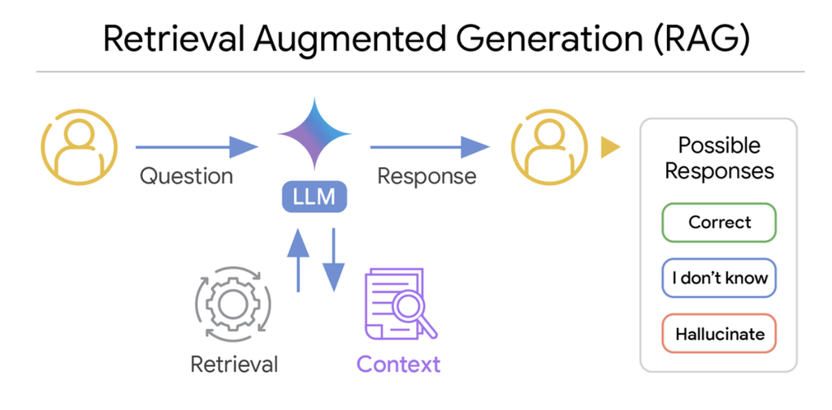

In a RAG system, an LLM uses retrieved context to provide a response to the input question

Source: [Google Research](https://research.google/blog/deeper-insights-into-retrieval-augmented-generation-the-role-of-sufficient-context/)

## Lecture overview

### Today’s agenda

**Part 1: The Problem**

- Quick recap: hallucinations (from Lecture 10)
- The knowledge cutoff issue
- How RAG solves both problems

**Part 2: Semantic Search**

- Finding by meaning, not just keywords
- Quick embeddings recap
- Why this matters for RAG

**Part 3: The RAG Pipeline**

- How documents become searchable
- Chunking, embedding, retrieving
- From question to grounded answer

**Part 4: No-Code Tools**

- NotebookLM, Perplexity
- Build your own RAG system today! 🛠️

## Meme of the day 😄

[figure not shown]

Source: [Bhavishya Pandit](https://bhavishyapandit9.substack.com/p/multimodal-retrieval-augmented-generation)

## Quick recap: Hallucinations 🤥

- LLMs are just pattern-matching machines. They:
  - Generate text that fits statistical expectations
  - Have no internal verification system for truth
- They’d rather make something up than admit ignorance
- Information from credible sources gets mixed with unreliable ones during training
- Fabricated answers sound just as convincing as accurate ones

**The main question for today:**

What if we could give the LLM access to real, verified information when answering?

[figure not shown]

What if the LLM could look things up before answering?

Source: [Iguazio](https://www.iguazio.com/glossary/llm-hallucination/)

## The solution: Give AI access to real information!

**RAG = Retrieval-Augmented Generation**

**The main idea:**

1. When you ask a question…
2. First search your documents for relevant information
3. Then give that information to the LLM
4. The LLM generates an answer using your data

**Why this works:**

- LLM gets real, up-to-date information
- Answers are grounded in your documents
- Can cite sources, so you can verify them!
- No need to retrain the model

It’s like giving the AI an open-book exam! 📖

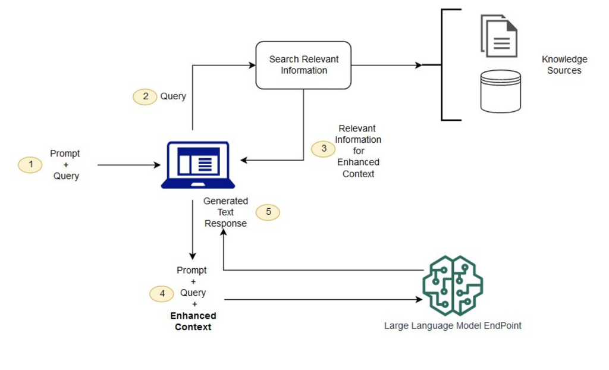

RAG concept diagram

Source: [AWS](https://aws.amazon.com/what-is/retrieval-augmented-generation/)

# Semantic Search 🔍

## Traditional search vs. semantic search

| Feature | Keyword Search | Semantic Search |
| --- | --- | --- |
| **Matching** | Exact words only | Meaning-based |
| **“cheap flights”** | ✅ “cheap flights” | ✅ “budget airfare” too! |
| **Synonyms** | ❌ Misses them | ✅ Understands them |
| **Typos** | ❌ Breaks results | ✅ Often still works |
| **Context** | ❌ Ignores it | ✅ Considers it |
| **Technology** | String matching | Embeddings |

**Example query**: “How do I fix a broken pipe?”

- Keyword search: Only finds documents with “broken pipe”
- Semantic search: Also finds “plumbing repair”, “leaky faucet solutions”

**Why does this matter for RAG?**

- Users ask questions in natural language
- Your documents may use different terminology
- Semantic search bridges this gap!

[figure not shown]

## How semantic search works: Embeddings

**Remember from Lecture 06?**

Text gets converted to vectors (lists of numbers):

| Text | Vector (simplified) |
| --- | --- |
| “king” | [0.82, 0.15, -0.43, …] |
| “queen” | [0.79, 0.18, -0.41, …] |
| “apple” | [-0.12, 0.67, 0.23, …] |

**Key properties:**

- Similar meanings → similar vectors
- “king” and “queen” are close in vector space
- “king” and “apple” are far apart
- Modern embedding models produce 768 to 3,072 dimensions

| Model | Dimensions | Use Case |
| --- | --- | --- |
| OpenAI ada-002 | 1,536 | General purpose |
| Google Gecko | 768 | Lightweight |
| Cohere Embed v3 | 1,024 | Multilingual |

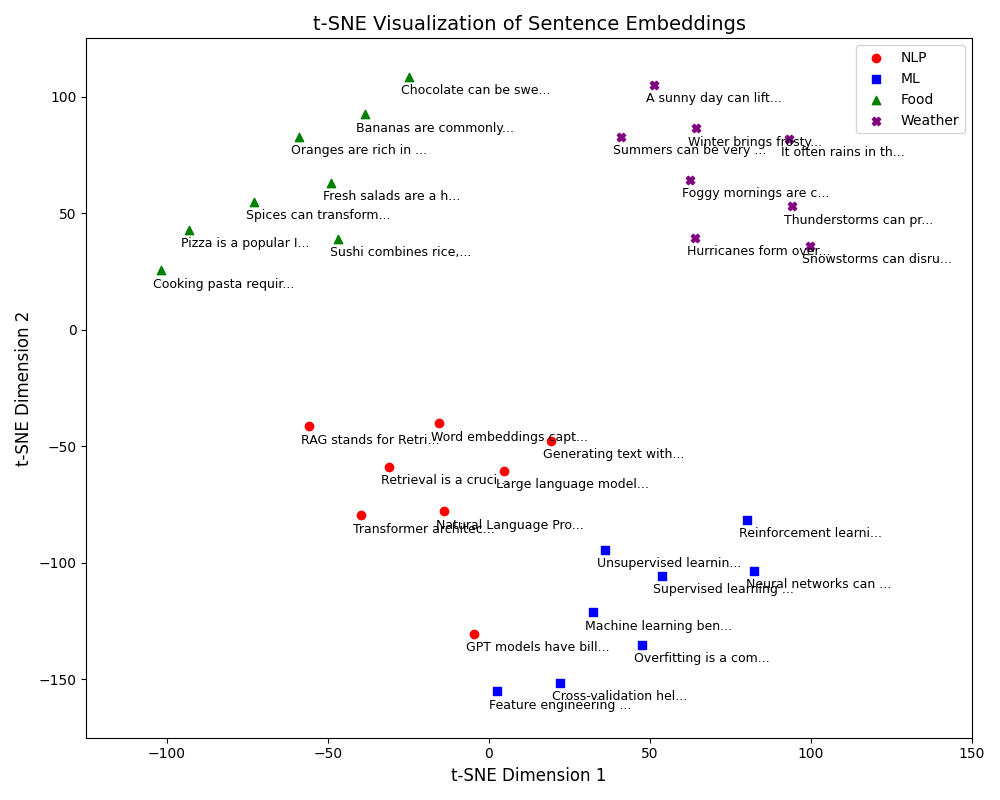

Sentence embeddings visualised

Similar sentences cluster together in embedding space

## Measuring similarity: Cosine similarity

**How do we measure if two vectors are similar?**

$$\text{similarity}(A, B) = \frac{A \cdot B}{\|A\| \times \|B\|}$$

**Interpretation:**

| Score | Meaning | Example |
| --- | --- | --- |
| 0.9–1.0 | Very similar | “car” vs “automobile” |
| 0.7–0.9 | Related | “car” vs “truck” |
| 0.4–0.7 | Loosely related | “car” vs “road” |
| 0.0–0.4 | Unrelated | “car” vs “banana” |

**In RAG systems:**

- Query embedding compared to all chunk embeddings
- Return chunks with highest similarity scores
- Typical threshold: retrieve if score > 0.7

**Mini-example (2D for simplicity):**

```
"I love dogs"  → [0.8, 0.6]
"I adore puppies" → [0.75, 0.65]
"The weather is nice" → [-0.3, 0.9]
```

The search finds “puppies” when you ask about “dogs”!

# The RAG Pipeline 🔄

## How RAG works

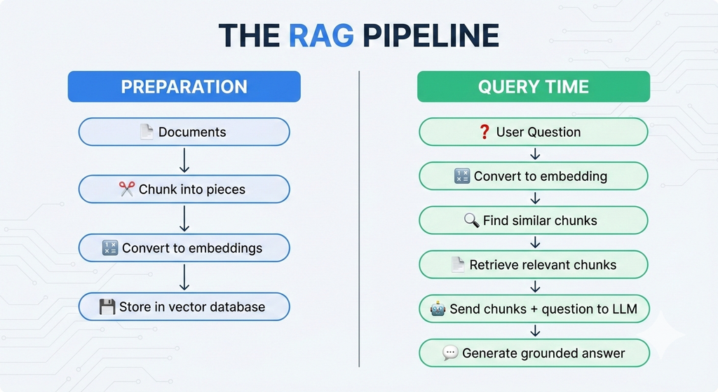

RAG pipeline

**Left side (once)**: Prepare your documents for searching

**Right side (every query)**: Find relevant info, then generate answer

The preparation work pays off because you only do it once; after that, every query is fast 📚

## Step 1: Ingest your documents

**What can you ingest?**

| Format | Examples | Challenges |
| --- | --- | --- |
| **PDF** | Papers, reports | Tables, columns, headers |
| **Word/Docs** | Reports, notes | Formatting, styles |
| **Web pages** | Articles, docs | Navigation, ads |
| **Code** | .py, .js files | Comments vs. code |
| **Transcripts** | Meeting notes | Speaker identification |

**The challenge:**

- Documents are unstructured
- Need to extract clean text
- Preserve meaningful structure

**Good news:** Tools like NotebookLM and ChatGPT handle extraction automatically!

[figure not shown]

Document ingestion

Many document types → unified text

## Step 2: Chunk the text

**Why chunk?**

**Chunking parameters:**

| Parameter | Typical Values | Trade-off |
| --- | --- | --- |
| **Chunk size** | 256–1,024 tokens | Small = precise, Large = more context |
| **Overlap** | 10–20% | Prevents losing info at boundaries |
| **Strategy** | Sentence, paragraph, semantic | Depends on document structure |

**Rule of thumb:** Start with 512 tokens, 20% overlap. Adjust based on your documents and retrieval quality.

**Chunk size trade-offs:**

| Size | Pros | Cons |
| --- | --- | --- |
| **Small (256)** | Precise retrieval | Loses context |
| **Medium (512)** | Balanced | Good default |
| **Large (1024)** | Rich context | May dilute relevance |

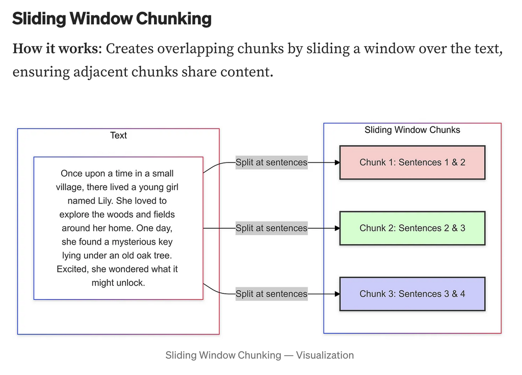

Chunking visualisation

Source: [Mastering LLM](https://masteringllm.medium.com/11-chunking-strategies-for-rag-simplified-visualized-df0dbec8e373)

## Step 3: Embed, store & retrieve

**Convert chunks to vectors & store:**

- Each chunk → embedding model → vector
- Same embedding model used for queries later!

| Database | Type | Speed (1M vectors) |
| --- | --- | --- |
| [Pinecone](https://pinecone.io/) | Cloud | ~50ms queries |
| [Chroma](https://www.trychroma.com/) | Local/Cloud | ~100ms queries |
| [FAISS](https://github.com/facebookresearch/faiss) | Local | ~10ms queries |

**Why vector databases?**

- Traditional databases: exact match
- Vector databases: similarity search

Don’t worry: no-code tools handle this for you!

**Retrieval (when you ask a question):**

1. Question → embedding → query vector
2. Vector DB finds similar chunks
3. Returns top-k most similar (k = 3–10)

**Example**: “What is our refund policy?”

| Rank | Chunk | Score |
| --- | --- | --- |
| 1 | “Returns and refunds: Customers may return…” | 0.92 |
| 2 | “Our guarantee covers full refunds…” | 0.87 |
| 3 | “Payment methods accepted…” | 0.54 ❌ |

**Parameters**: top-k (3–10), threshold (0.7–1.0)

## Step 4: Generate with context

**The final step:**

The LLM receives a prompt like this:

**System**: Answer the user’s question using ONLY the context provided. If the answer isn’t in the context, say “I don’t have that information.”

**Context**: [Chunk 1]: “Returns and refunds: Customers may return items within 30 days…”. [Chunk 2]: “Our guarantee covers full refunds for defective products…”

**User question**: “What is your refund policy?”

**The LLM now:**

- Has specific, relevant information to work with
- Is instructed to cite sources
- Is told to say “I don’t know” if context doesn’t contain the answer
- Generates a grounded response

[figure not shown]

Context injection

Retrieved chunks become the LLM’s “reference material”

This is why RAG reduces hallucinations: the LLM answers from your documents instead of guessing from its training data

# RAG vs. Alternatives 🔄

## RAG vs. fine-tuning vs. prompting

**Three ways to customise LLM behaviour:**

| Aspect | Prompt Engineering | RAG | Fine-tuning |
| --- | --- | --- | --- |
| **What it does** | Careful instructions | Add external knowledge | Retrain model weights |
| **Cost** | Free or $ | $ | $$$ |
| **Setup time** | Minutes | Hours | Days–Weeks |
| **Data freshness** | Training cutoff | Real-time | Training cutoff |
| **Accuracy (domain)** | Low–Medium | High | High |
| **Hallucination risk** | High | Low | Medium |
| **Cites sources** | ❌ | ✅ | ❌ |
| **Best for** | Simple tasks | Knowledge-intensive QA | Style/behaviour change |

**When to use each:**

- Prompting: Quick experiments, general tasks, no private data
- RAG: Customer support, research, legal/medical QA, any task needing current or private information
- Fine-tuning: Specific writing style, consistent persona, specialised domain language

## Research findings: Does RAG actually help?

**Yes! The evidence is strong:**

| Study | Finding |
| --- | --- |
| [Lewis et al. (2020)](https://arxiv.org/abs/2005.11401) | Original RAG paper: outperformed fine-tuned models on knowledge-intensive tasks |
| [Shuster et al. (2021)](https://arxiv.org/abs/2104.07567) | RAG reduced hallucinations by ~30–50% in dialogue systems |
| [Gao et al. (2024)](https://arxiv.org/abs/2312.10997) | Comprehensive survey: RAG approach dominant in production systems |
| [Liu et al. (2023)](https://arxiv.org/abs/2307.03172) | “Lost in the middle”: LLMs use beginning and end of context better than middle |

**Hallucination rates comparison:**

| Setting | Hallucination Rate |
| --- | --- |
| Base LLM (no RAG) | 15–40% |
| LLM + RAG | 5–15% |
| LLM + RAG + verification | 2–8% |

*Rates vary by domain and implementation quality*

**The “Lost in the Middle” problem:**

[Liu et al. (2023)](https://arxiv.org/abs/2307.03172) found that LLMs pay most attention to:

1. Beginning of context (primacy)
2. End of context (recency)
3. Middle is often ignored!

**Implication for RAG:**

Put the most relevant chunks first or last, not in the middle!

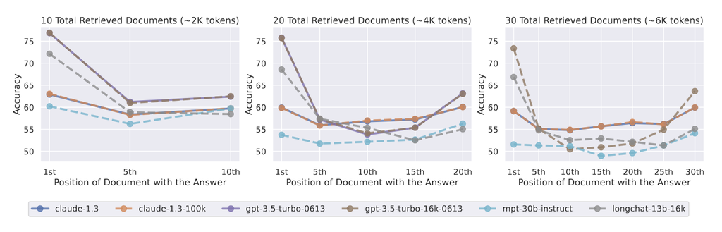

Lost in the middle effect

Source: [Liu et al. (2023)](https://arxiv.org/abs/2307.03172)

# RAG Failure Modes ⚠️

## When RAG goes wrong

**RAG isn’t perfect. Common failure modes:**

| Failure Type | What Happens | Frequency |
| --- | --- | --- |
| **Retrieval failure** | Wrong chunks retrieved | 15–25% of queries |
| **Lost in the middle** | Relevant info in middle ignored | Common with many chunks |
| **Context overflow** | Too much text, truncated | Depends on doc size |
| **Outdated docs** | Stale information retrieved | Depends on maintenance |
| **Extraction errors** | PDF tables/images parsed incorrectly | 10–30% of complex docs |

**Retrieval failures happen when:**

- Query uses different terms than documents
- Question is ambiguous
- Multiple topics compete for relevance
- Embedding model doesn’t capture domain-specific meaning

**Example: Retrieval failure**

**Your document says:** > “The quarterly earnings call is scheduled for March 15th”

**You ask:** > “When is the investor meeting?”

**Problem:** “investor meeting” ≠ “earnings call” in embedding space

**Result:** Wrong chunks retrieved, wrong answer!

**Mitigation strategies:**

- Use terms from your documents
- Add synonyms to your documents
- Use hybrid search (keyword + semantic)
- Increase top-k (retrieve more chunks)

## Best practices for reliable RAG

**For document preparation:**

1. **Clean your documents**
   - Remove headers, footers, page numbers
   - Fix OCR errors in scanned PDFs
2. **Use descriptive headings**
   - Helps chunking and retrieval
   - “Q4 2024 Revenue” > “Section 3.2”
3. **Keep documents updated**
   - Stale docs = stale answers
   - Version control your knowledge base
4. **Test with real queries**
   - What questions will users actually ask?
   - Do retrieved chunks contain the answer?

**For querying:**

1. **Be specific**
   - ✅ “What was Q4 2024 revenue?”
   - ❌ “Tell me about the company”
2. **Use document terminology**
   - If doc says “associates”, ask about “associates” not “employees”
3. **Check the citations!**
   - Does the answer match what the source says?
   - This is your verification step
4. **Ask follow-up questions**
   - “What source did you use for that?”
   - “Can you quote the relevant passage?”

**Golden rule:** Trust, but verify 🔍

# No-Code RAG Tools 🛠️

## Tools you can use today!

| Tool | Free? | Best For | Key Feature |
| --- | --- | --- | --- |
| [NotebookLM](https://notebooklm.google.com/) | ✅ Yes | Research, study notes | Multi-source synthesis |
| [ChatGPT + Files](https://chat.openai.com/) | ✅ Free tier | General documents | Easy upload & chat |
| [Claude + Files](https://claude.ai/) | ✅ Free tier | Long documents | 200K token context |
| [Google AI Studio](https://aistudio.google.com/) | ✅ Free tier | Experimentation | Gemini models |

**All of these implement RAG internally!**

- You upload documents → (Retrieval source)
- System finds relevant parts → (Augmented)
- LLM generates answers → (Generation)

No coding required, just upload and ask!

## NotebookLM: Your AI research assistant

**What is NotebookLM?**

- Free tool from Google
- Upload up to 50 sources (PDFs, docs, websites, YouTube)
- Creates a personal knowledge base
- AI answers questions from YOUR sources only

**Features:**

| Feature | What It Does |
| --- | --- |
| **Source grounding** | Only answers from your docs |
| **Citations** | Points to exact source passages |
| **Audio Overview** | Generates podcast-style summary |
| **Study guides** | Creates questions & summaries |
| **Cross-referencing** | Finds connections between sources |

**Best for:** Research projects, exam prep, literature reviews, understanding complex reports

[figure not shown]

NotebookLM interface

[notebooklm.google.com](https://notebooklm.google.com/)

## Activity: Z.ai file upload RAG 📎

**Compare: With vs. without your documents. Let’s do it together (or at home if Emory’s connection doesn’t allow us to! 😂)**

**Step 1: Without documents**

1. Open [chat.z.ai](https://chat.z.ai/)
2. Start a new chat
3. Ask: “What are the assignment deadlines for DATASCI 101 at Emory University?”
4. Note: Z.ai doesn’t know! (It’s not in training data)

**Step 2: With your document**

1. Start another new chat
2. Click the 📎 (attach) button
3. Upload the course syllabus PDF
4. Ask the same question: “What are the assignment deadlines?”
5. Compare the answers

**What to observe:**

| Without Doc | With Doc |
| --- | --- |
| “I don’t have access to…” | Specific dates from syllabus |
| May hallucinate generic answer | Grounded in your document |
| No citations | Can quote the source |

**This is RAG in action!**

The LLM retrieves relevant parts of your uploaded file and uses them to generate an accurate answer.

You just built a RAG system! 🎉

# Real-World Applications 🌍

## RAG is everywhere!

| Industry | Application | How RAG Helps | Example Company |
| --- | --- | --- | --- |
| 🏢 **Customer Support** | AI chatbots | Answer questions from product docs | Intercom, Zendesk |
| ⚖️ **Legal** | Research assistants | Search case law by meaning | Harvey AI, Casetext |
| 🏥 **Healthcare** | Clinical support | Find relevant patient records, guidelines | Epic, Nuance |
| 📚 **Education** | Personal tutors | Answer questions from course materials | Khan Academy, Duolingo |
| 💼 **Finance** | Analyst tools | Search earnings reports, SEC filings | Bloomberg, Kensho |
| 🔬 **Research** | Literature review | Find related papers, summarise findings | Elicit, Semantic Scholar |
| 💻 **Developer Tools** | Documentation QA | Answer questions from codebases | GitHub Copilot, Cursor |

In each case, the user needs answers grounded in specific documents, and the system needs to cite where the answer came from

**Market size**: Enterprise RAG solutions expected to reach $40B+ by 2028 (estimates vary)

**Advanced RAG**: [LangChain](https://www.langchain.com/) is a popular framework for building RAG applications. Feel free to explore it if you’re familiar with Python/JavaScript and want to build your own RAG system!

# Summary 📚

## Key takeaways

- **The problem**: LLMs hallucinate and lack access to private/current information
- **Semantic search**: Find by meaning using embeddings and cosine similarity
- **The RAG pipeline**: Chunk → Embed → Store → Retrieve → Generate
- **Research shows**: RAG reduces hallucinations by 30–50%
- **Watch out for**: Retrieval failures, lost-in-the-middle, outdated docs
- **No-code tools**: NotebookLM, ChatGPT with files, etc
- **Always verify**: RAG reduces errors but doesn’t eliminate them!

**Quick reference:**

| Concept | Key Numbers |
| --- | --- |
| Cosine similarity | 0.9+ = very similar |
| Chunk size | 256–1024 tokens |
| Overlap | 10–20% |
| Top-k retrieval | 3–10 chunks |
| Hallucination reduction | 30–50% |

**Remember:** Upload your docs, ask specific questions, and always check citations!

# …and that’s all for today! 🎉